# 1. Healthcare expenditure, and meeting increasing demand.

# 2. Omnibus Survey Dataset

This Dataset is about the knowledge and awareness of certain genders and age-groups of trans-fat and wholegrain.

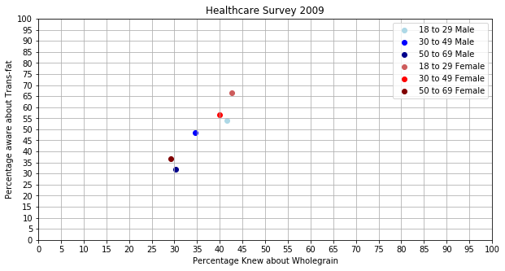

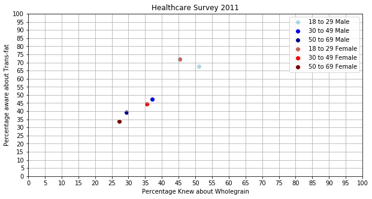

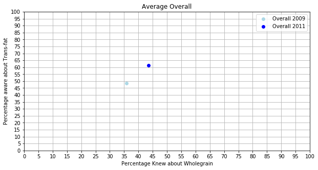

```python
import pandas as pd
import numpy as np
import matplotlib.pyplot as plt

df_aware = pd.read_csv('omnibus-survey-2009-2011.csv').set_index('year')

color = ['lightblue','blue','darkblue','indianred','red','maroon']
df_aware_gender_overall = df_aware[df_aware.loc[:,"gender"] == "Overall"];
df_aware_gender_2009 = df_aware[np.logical_and(df_aware.loc[:,"age_group"] != "Overall",df_aware.index == 2009)]
df_aware_gender_2011 = df_aware[np.logical_and(df_aware.loc[:,"age_group"] != "Overall",df_aware.index == 2011)]

plt.figure(figsize=(10, 5))
for label in np.arange(0,df_aware_gender_2011.loc[:,"knowledge_on_wholegrain"].to_numpy().size,1):
    plt.scatter(df_aware_gender_2009.loc[:,"knowledge_on_wholegrain"].to_numpy()[label]*100,
                df_aware_gender_2009.loc[:,"aware_of_transfat"].to_numpy()[label]*100,
                label=df_aware_gender_2009.loc[:,"age_group"].to_numpy()[label]+" "+df_aware_gender_2009.loc[:,"gender"].to_numpy()[label],
                c=color[label])
plt.xlabel("Percentage Knew about Wholegrain")
plt.ylabel("Percentage aware about Trans-fat")
plt.title("Healthcare Survey 2009")
plt.legend(loc="best")
plt.yticks(np.arange(0,105,5))
plt.xticks(np.arange(0,105,5))
plt.grid()

plt.figure(figsize=(10, 5))
for label in np.arange(0,df_aware_gender_2011.loc[:,"knowledge_on_wholegrain"].to_numpy().size,1):
    plt.scatter(df_aware_gender_2011.loc[:,"knowledge_on_wholegrain"].to_numpy()[label]*100,
                df_aware_gender_2011.loc[:,"aware_of_transfat"].to_numpy()[label]*100,
                label=df_aware_gender_2011.loc[:,"age_group"].to_numpy()[label]+" "+df_aware_gender_2011.loc[:,"gender"].to_numpy()[label],
                c=color[label])
plt.xlabel("Percentage Knew about Wholegrain")
plt.ylabel("Percentage aware about Trans-fat")
plt.title("Healthcare Survey 2011")
plt.legend(loc="best")
plt.yticks(np.arange(0,105,5))
plt.xticks(np.arange(0,105,5))
plt.grid()

plt.figure(figsize=(10, 5))
for label in np.arange(0,df_aware_gender_overall.loc[:,"knowledge_on_wholegrain"].to_numpy().size,1):
    plt.scatter(df_aware_gender_overall.loc[:,"knowledge_on_wholegrain"].to_numpy()[label]*100,
                df_aware_gender_overall.loc[:,"aware_of_transfat"].to_numpy()[label]*100,
                label=df_aware_gender_overall.loc[:,"gender"].to_numpy()[label]+" "+str(df_aware_gender_overall.index[label]),
                c=color[label])
plt.xlabel("Percentage Knew about Wholegrain")
plt.ylabel("Percentage aware about Trans-fat")
plt.title("Average Overall")
plt.legend(loc="best")
plt.yticks(np.arange(0,105,5))
plt.xticks(np.arange(0,105,5))
plt.grid()
```

# 3.Omnibus Survey Dataset in Detail and Conclusion

For this dataset, I had to manually create a color array.  
I then sorted the dataset into its seperate years.  
I used a for-loop to plot each graph.  
I used the dataframe and converted it into a numpy and got its size via .size, I used this to control the for loop.  
I then used the knowledge of wholegrain as the x axis and awareness of transfat as the y axis.  
For the labels, I used the age_groups column and the gender column in combination to produce the legend.  
I also used the color array to color each dot on the scatter graph.

We should now be able to answer the questions posed at the start:

**-Are the younger generations more informed about healthy eating than older generations?**  
Using both graphs, we can see that in 2009, those in the 18-29 age range have higher percentages than their older counterparts, especially the 50-69 age range.  
In 2011, this difference is even more pronounced. The 18-29 Age range is clearly ahead of their older counter-parts. In conclusion, the younger generations are more informed about healthy eating than older generations.

**-Are Males more likely to know about Healthy eating than Females?**  
In 2009,  
50-69 Females are more likely to be aware of Transfat than Males of the same age range  
.However, the Opposite is true for Wholegrain. The Transfat difference is larger compared to the Wholegrain one.  
30-49 Females have a larger percentage to be aware of wholegrain and transfat compared to their Male counterparts who lag behind quite Significantly.  
18-29 Females again are more likely to be aware of Transfat and Wholegrain than their Male counterparts who are surpassed in knowledge about Trans-fat by 30-49 Females. 18-29 Females surpass 18-29 Males in the knowledge about Wholegrain and surpass 18-29 in transfat greatly, by slightly more than 10%.  
In 2011,  
50-69 Females are outclassed by their Male counter parts, especially in Transfat, where the Males have a 5% advantage.  
30-49 Females are again outclassed by their Male counterparts. However this time they are much closer together, each subject not having as much as a 5% difference.  
In the 18-29 age range, there is some interesting data.  
The Males now have approximately 5% more percentage than the Females, but the Female percentage for Transfat is still above the Males.  
In conclusion, the Females overall have a higher percentage of their own gender knowing about Transfat and Wholegrain.  
Males sometimes could know more about Wholegrain but it was largely Female dominated,  
especially the percentage on knowledge of Transfat. This could be due to Females watching their food intake more often or other factors.  
Source :https://cdn.intechopen.com/pdfs/36935/InTech-Gender_differences_in_food_choice_and_dietary_intake_in_modern_western_societies.pdf  
**-Has the population been more informed about Healthy eating in 2011 than in 2009?**  
First, I will go through a analysis of the 2009 and 2011 graphs. In 2009,  
the 50-69 age group hovered around 35% for Transfat and 30% for Wholegrain.  
the 30-49 age group hovered around 50% for Transfat and 35% for Wholegrain for Males, and 55% for Transfat and 40% for Wholegrain for Females.  
the 18-29 age group hovered around 55% for Transfat and around 42% for Wholegrain for Males, and 65% for Transfat and 43% for Wholegrain for Females.  
In 2011,  
the 50-69 age group hovered around 35%-40% for Transfat and 25%-30% for Wholegrain.  
the 30-49 age group hovered around 45% for Transfat and 35% for Wholegrain.  
the 18-29 age group hovered around 65% for Transfat and 50% for Wholegrain for Males, and 70% for Transfat and 45% for Wholegrain for Females

Now I will use the Overall as it was provided in the Dataset.  
In 2009, Around 50% knew about Transfat and 35% knew about Wholegrain.  
In 2011, Around 60% knew about Transfat and 40% knew about Wholegrain.  
This constitutes an increase in the amount of public being informed about the subjects stated.

I will conclude that there is an increase, this is especially prominent in the 18-29 age group and if the overall graph is consulted. The decreases could be explained by differing sample sizes and other factors that I do not have access too.

In conclusion, the population has been more informed about Healthy eating in 2011 than in 2009.